# Google Playstore Case Study

In this module you’ll be learning data visualisation with the help of a case study. This will enable you to understand how visualisation aids you in solving business problems.

**Problem Statement**

The team at Google Play Store wants to develop a feature that would enable them to boost visibility for the most promising apps. Now, this analysis would require a preliminary understanding of the features that define a well-performing app. You can ask questions like:

- Does a higher size or price necessarily mean that an app would perform better than the other apps?
- Or does a higher number of installs give a clear picture of which app would have a better rating than others?

### Session 1 - Introduction to Data Visualisation

```python
#import the libraries
import numpy as np
import pandas as pd
import matplotlib.pyplot as plt
```

```python
#read the dataset and check the first five rows
inp0 = pd.read_csv('googleplaystore_v2.csv', header=0)
inp0.head()
```

|  | App | Category | Rating | Reviews | Size | Installs | Type | Price | Content Rating | Genres | Last Updated | Current Ver | Android Ver |
| --- | --- | --- | --- | --- | --- | --- | --- | --- | --- | --- | --- | --- | --- |
| 0 | Photo Editor & Candy Camera & Grid & ScrapBook | ART_AND_DESIGN | 4.1 | 159 | 19000.0 | 10,000+ | Free | 0 | Everyone | Art & Design | January 7, 2018 | 1.0.0 | 4.0.3 and up |
| 1 | Coloring book moana | ART_AND_DESIGN | 3.9 | 967 | 14000.0 | 500,000+ | Free | 0 | Everyone | Art & Design;Pretend Play | January 15, 2018 | 2.0.0 | 4.0.3 and up |
| 2 | U Launcher Lite – FREE Live Cool Themes, Hide ... | ART_AND_DESIGN | 4.7 | 87510 | 8700.0 | 5,000,000+ | Free | 0 | Everyone | Art & Design | August 1, 2018 | 1.2.4 | 4.0.3 and up |
| 3 | Sketch - Draw & Paint | ART_AND_DESIGN | 4.5 | 215644 | 25000.0 | 50,000,000+ | Free | 0 | Teen | Art & Design | June 8, 2018 | Varies with device | 4.2 and up |
| 4 | Pixel Draw - Number Art Coloring Book | ART_AND_DESIGN | 4.3 | 967 | 2800.0 | 100,000+ | Free | 0 | Everyone | Art & Design;Creativity | June 20, 2018 | 1.1 | 4.4 and up |

```python
#Check the shape of the dataframe
inp0.shape
```

```
(10841, 13)
```

### Data Handling and Cleaning

The first few steps involve making sure that there are no **missing values** or **incorrect data types** before we proceed to the analysis stage. These aforementioned problems are handled as follows:

- For Missing Values: Some common techniques to treat this issue are
  - Dropping the rows containing the missing values
  - Imputing the missing values
  - Keep the missing values if they don't affect the analysis
- Incorrect Data Types:
  - Clean certain values
  - Clean and convert an entire column

```python
#Check the datatypes of all the columns of the dataframe
inp0.info()
```

```
<class 'pandas.core.frame.DataFrame'>
RangeIndex: 10841 entries, 0 to 10840
Data columns (total 13 columns):
 #   Column          Non-Null Count  Dtype
---  ------          --------------  -----
 0   App             10841 non-null  object
 1   Category        10841 non-null  object
 2   Rating          9367 non-null   float64
 3   Reviews         10841 non-null  object
 4   Size            10841 non-null  float64
 5   Installs        10841 non-null  object
 6   Type            10840 non-null  object
 7   Price           10841 non-null  object
 8   Content Rating  10840 non-null  object
 9   Genres          10841 non-null  object
 10  Last Updated    10841 non-null  object
 11  Current Ver     10833 non-null  object
 12  Android Ver     10838 non-null  object
dtypes: float64(2), object(11)
memory usage: 1.1+ MB
```

#### Missing Value Treatment

```python
#Check the number of null values in the columns
inp0.isnull().sum()
```

```
App                  0
Category             0
Rating            1474
Reviews              0
Size                 0
Installs             0
Type                 1
Price                0
Content Rating       1
Genres               0
Last Updated         0
Current Ver          8
Android Ver          3
dtype: int64
```

Handling missing values for rating

- Ratings is the target variable
- drop the records

```python
#Drop the rows having null values in the Rating field
inp1 = inp0[~ inp0.Rating.isnull()]


#Check the shape of the dataframe
inp1.shape
```

```
(9367, 13)
```

```python
# Check the number of nulls in the Rating field again to cross-verify
inp1.Rating.isnull().sum()
```

```
0
```

```python
#Question
#Check the number of nulls in the dataframe again and find the total number of null values

inp1.isnull().sum()
```

```
App               0
Category          0
Rating            0
Reviews           0
Size              0
Installs          0
Type              0
Price             0
Content Rating    1
Genres            0
Last Updated      0
Current Ver       4
Android Ver       3
dtype: int64
```

```python
#Inspect the nulls in the Android Version column
inp1[inp1['Android Ver'].isnull()]
```

|  | App | Category | Rating | Reviews | Size | Installs | Type | Price | Content Rating | Genres | Last Updated | Current Ver | Android Ver |
| --- | --- | --- | --- | --- | --- | --- | --- | --- | --- | --- | --- | --- | --- |
| 4453 | [substratum] Vacuum: P | PERSONALIZATION | 4.4 | 230 | 11000.000000 | 1,000+ | Paid | $1.49 | Everyone | Personalization | July 20, 2018 | 4.4 | NaN |
| 4490 | Pi Dark [substratum] | PERSONALIZATION | 4.5 | 189 | 2100.000000 | 10,000+ | Free | 0 | Everyone | Personalization | March 27, 2018 | 1.1 | NaN |
| 10472 | Life Made WI-Fi Touchscreen Photo Frame | 1.9 | 19.0 | 3.0M | 21516.529524 | Free | 0 | Everyone | NaN | February 11, 2018 | 1.0.19 | 4.0 and up | NaN |

```python
#Drop the row having shifted values
inp1 = inp1[~( (inp1['Android Ver'].isnull())   & (inp1['Category']== '1.9'))]


#Check the nulls againin Android version column to cross-verify
print(inp1['Android Ver'].isnull().sum())
inp1[inp1['Android Ver'].isnull()]
```

```
2
```

|  | App | Category | Rating | Reviews | Size | Installs | Type | Price | Content Rating | Genres | Last Updated | Current Ver | Android Ver |
| --- | --- | --- | --- | --- | --- | --- | --- | --- | --- | --- | --- | --- | --- |
| 4453 | [substratum] Vacuum: P | PERSONALIZATION | 4.4 | 230 | 11000.0 | 1,000+ | Paid | $1.49 | Everyone | Personalization | July 20, 2018 | 4.4 | NaN |
| 4490 | Pi Dark [substratum] | PERSONALIZATION | 4.5 | 189 | 2100.0 | 10,000+ | Free | 0 | Everyone | Personalization | March 27, 2018 | 1.1 | NaN |

Imputing Missing Values

- For numerical variables use mean and median
- For categorical variables use mode

```python
#Check the most common value in the Android version column
inp1['Android Ver'].value_counts()
mode_value = inp1['Android Ver'].mode()[0]
mode_value
```

```
'4.1 and up'
```

```python
#Fill up the nulls in the Android Version column with the above value
inp1['Android Ver'] = inp1['Android Ver'].fillna(mode_value)
```

```python
#Check the nulls in the Android version column again to cross-verify
inp1['Android Ver'].isnull().sum()
```

```
0
```

```python
#Check the nulls in the entire dataframe again
inp1.isnull().sum()
```

```
App               0
Category          0
Rating            0
Reviews           0
Size              0
Installs          0
Type              0
Price             0
Content Rating    0
Genres            0
Last Updated      0
Current Ver       4
Android Ver       0
dtype: int64
```

```python
#Check the most common value in the Current version column
inp1['Current Ver'].value_counts()
current_mode_value = inp1['Current Ver'].mode()[0]
current_mode_value
```

```
'Varies with device'
```

```python
#Replace the nulls in the Current version column with the above value

inp1['Current Ver'] =inp1['Current Ver'].fillna(current_mode_value)
```

```python
# Question : Check the most common value in the Current version column again
inp1['Current Ver'].value_counts()
```

```
Varies with device    1419
1.0                    458
1.1                    195
1.2                    126
1.3                    120
                      ...
2.9.10                   1
3.18.5                   1
1.3.A.2.9                1
9.9.1.1910               1
0.3.4                    1
Name: Current Ver, Length: 2638, dtype: int64
```

#### Handling Incorrect Data Types

```python
#Check the datatypes of all the columns
inp1.dtypes
```

```
App                object
Category           object
Rating            float64
Reviews            object
Size              float64
Installs           object
Type               object
Price              object
Content Rating     object
Genres             object
Last Updated       object
Current Ver        object
Android Ver        object
dtype: object
```

```python
#Question - Try calculating the average price of all apps having the Android version as "4.1 and up"

# avg_price = inp1[inp1['Android Ver'] == '4.1 and up']['Price'].mean() // error
```

```python
#Analyse the Price column to check the issue
inp1.Price.value_counts()
```

```
0          8719
$2.99       114
$0.99       107
$4.99        70
$1.99        59
           ...
$1.29         1
$299.99       1
$379.99       1
$37.99        1
$1.20         1
Name: Price, Length: 73, dtype: int64
```

```python
#Write the function to make the changes

inp1.Price = inp1.Price.apply(lambda x: 0 if x=='0' else float(x[1:]))
```

```python
#Verify the dtype of Price once again
inp1.Price.dtypes
```

```
dtype('float64')
```

```python
#Analyse the Reviews column
inp1.Reviews.value_counts()
```

```
2         83
3         78
4         74
5         74
1         67
          ..
49657      1
41420      1
7146       1
44706      1
398307     1
Name: Reviews, Length: 5992, dtype: int64
```

```python
#Change the dtype of this column
inp1.Reviews = inp1.Reviews.astype("int")
inp1.Reviews.dtypes

#Check the quantitative spread of this dataframe

inp1.Reviews.describe()
```

```
count    9.366000e+03
mean     5.140498e+05
std      3.144042e+06
min      1.000000e+00
25%      1.862500e+02
50%      5.930500e+03
75%      8.153275e+04
max      7.815831e+07
Name: Reviews, dtype: float64
```

```python
#Analyse the Installs Column
inp1.Installs.value_counts()
```

```
1,000,000+        1577
10,000,000+       1252
100,000+          1150
10,000+           1010
5,000,000+         752
1,000+             713
500,000+           538
50,000+            467
5,000+             432
100,000,000+       409
100+               309
50,000,000+        289
500+               201
500,000,000+        72
10+                 69
1,000,000,000+      58
50+                 56
5+                   9
1+                   3
Name: Installs, dtype: int64
```

```python
#Question Clean the Installs Column and find the approximate number of apps at the 50th percentile.
inp1.Installs = inp1.Installs.apply(lambda x: x.replace(',',"").replace('+',''))
inp1.Installs = inp1.Installs.astype("int")
inp1.Installs.describe()
```

```
count    9.366000e+03
mean     1.789744e+07
std      9.123822e+07
min      1.000000e+00
25%      1.000000e+04
50%      5.000000e+05
75%      5.000000e+06
max      1.000000e+09
Name: Installs, dtype: float64
```

```python
inp1.dtypes
```

```
App                object
Category           object
Rating            float64
Reviews             int32
Size              float64
Installs            int32
Type               object
Price             float64
Content Rating     object
Genres             object
Last Updated       object
Current Ver        object
Android Ver        object
dtype: object
```

#### Sanity Checks

The data that we have needs to make sense and therefore you can perform certain sanity checks on them to ensure they are factually correct as well. Some sanity checks can be:

- Rating is between 1 and 5 for all the apps.
- Number of Reviews is less than or equal to the number of Installs.
- Free Apps shouldn’t have a price greater than 0.

```python
# saity check on ratings - Average rating should be betwwen 1 and 5
inp1.Rating.describe()
```

```
count    9366.000000
mean        4.191757
std         0.515219
min         1.000000
25%         4.000000
50%         4.300000
75%         4.500000
max         5.000000
Name: Rating, dtype: float64
```

```python
#Perform the sanity checks on the Reviews column - it should be <= installs
inp1[(inp1.Reviews > inp1.Installs)] # Around 7 records


## lets drop these records
inp1 = inp1[(inp1.Reviews <= inp1.Installs)]

## lets recheck
inp1[(inp1.Reviews > inp1.Installs)].shape
```

```
(0, 13)
```

```python
#perform the sanity checks on prices of free apps - price should not be more than zero


inp1[(inp1.Type == 'Free') & (inp1.Price > 0)]
```

|  | App | Category | Rating | Reviews | Size | Installs | Type | Price | Content Rating | Genres | Last Updated | Current Ver | Android Ver |
| --- | --- | --- | --- | --- | --- | --- | --- | --- | --- | --- | --- | --- | --- |

```python
## DOUBT : should be need to remove the duplicates from the App column

inp1.head()

inp1.App.value_counts()
```

```
ROBLOX                                               9
CBS Sports App - Scores, News, Stats & Watch Live    8
Candy Crush Saga                                     7
ESPN                                                 7
8 Ball Pool                                          7
                                                    ..
Kpop Music Quiz (K-pop Game)                         1
OST)                                                 1
Preschool All-In-One                                 1
K-Chiing VPN (Free)                                  1
iHoroscope - 2018 Daily Horoscope & Astrology        1
Name: App, Length: 8189, dtype: int64
```

#### Outliers Analysis Using Boxplot

Now you need to start identifying and removing extreme values or **outliers** from our dataset. These values can tilt our analysis and often provide us with a biased perspective of the data available. This is where you’ll start utilising visualisation to achieve your tasks. And the best visualisation to use here would be the box plot. Boxplots are one of the best ways of analysing the spread of a numeric variable

Using a box plot you can identify the outliers as follows:

[figure not shown]

- Outliers in data can arise due to genuine reasons or because of dubious entries. In the latter case, you should go ahead and remove such entries immediately. Use a boxplot to observe, analyse and remove them.
- In the former case, you should determine whether or not removing them would add value to your analysis procedure.
- You can create a box plot directly from pandas dataframe or the matplotlib way as you learnt in the previous session. Check out their official documentation here:
  - https://pandas.pydata.org/pandas-docs/stable/reference/api/pandas.DataFrame.boxplot.html
  - https://matplotlib.org/3.1.1/api/_as_gen/matplotlib.pyplot.boxplot.html

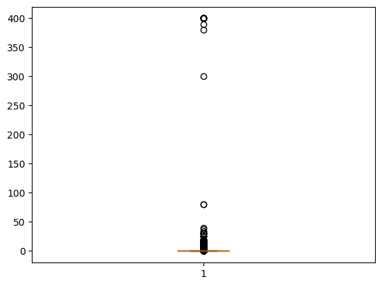

```python
#import the plotting libraries
import matplotlib.pyplot as plt
%matplotlib inline

plt.boxplot(inp1.Price)
plt.show()
```

```python
#Create a box plot for the price column
inp1.Price.describe()
IQR = 0 - 0
```

```python
#Check the apps with price more than 200
inp1[inp1.Price > 200][['App','Price']].shape
```

```
(15, 2)
```

```python
#Clean the Price column
inp1 = inp1[inp1.Price < 200]
```

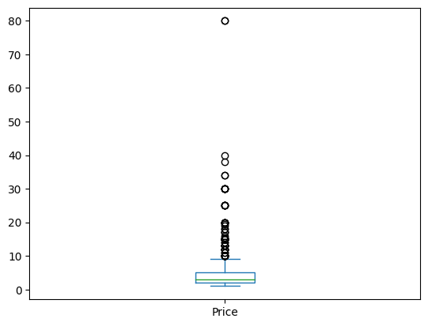

```python
#Create a box plot for paid apps

inp1[inp1.Price > 0].Price.plot.box()
```

```python
#Check the apps with price more than 30
inp1[inp1.Price > 30]
```

|  | App | Category | Rating | Reviews | Size | Installs | Type | Price | Content Rating | Genres | Last Updated | Current Ver | Android Ver |
| --- | --- | --- | --- | --- | --- | --- | --- | --- | --- | --- | --- | --- | --- |
| 2253 | Vargo Anesthesia Mega App | MEDICAL | 4.6 | 92 | 32000.0 | 1000 | Paid | 79.99 | Everyone | Medical | June 18, 2018 | 19.0 | 4.0.3 and up |
| 2301 | A Manual of Acupuncture | MEDICAL | 3.5 | 214 | 68000.0 | 1000 | Paid | 33.99 | Everyone | Medical | October 2, 2017 | 2.1.35 | 4.0 and up |
| 2365 | Vargo Anesthesia Mega App | MEDICAL | 4.6 | 92 | 32000.0 | 1000 | Paid | 79.99 | Everyone | Medical | June 18, 2018 | 19.0 | 4.0.3 and up |
| 2402 | A Manual of Acupuncture | MEDICAL | 3.5 | 214 | 68000.0 | 1000 | Paid | 33.99 | Everyone | Medical | October 2, 2017 | 2.1.35 | 4.0 and up |
| 2414 | LTC AS Legal | MEDICAL | 4.0 | 6 | 1300.0 | 100 | Paid | 39.99 | Everyone | Medical | April 4, 2018 | 3.0.1 | 4.1 and up |
| 5360 | I am Rich Person | LIFESTYLE | 4.2 | 134 | 1800.0 | 1000 | Paid | 37.99 | Everyone | Lifestyle | July 18, 2017 | 1.0 | 4.0.3 and up |

```python
#Clean the Price column again
inp1 = inp1[inp1.Price <= 30]
inp1.shape
```

```
(9338, 13)
```

### Histograms

Histograms can also be used in conjuction with boxplots for data cleaning and data handling purposes. You can use it to check the spread of a numeric variable. Histograms generally work by bucketing the entire range of values that a particular variable takes to specific **bins**. After that, it uses vertical bars to denote the total number of records in a specific bin, which is also known as its **frequency**.

[figure not shown]

You can adjust the number of bins to improve its granularity

[figure not shown]

You'll be using plt.hist() to plot a histogram. Check out its official documentation:https://matplotlib.org/3.1.1/api/_as_gen/matplotlib.pyplot.hist.html

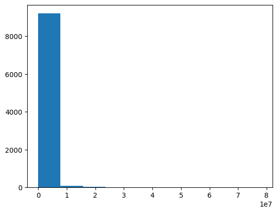

```python
#Create a histogram of the Reviews
plt.hist(inp1.Reviews)
plt.show()
```

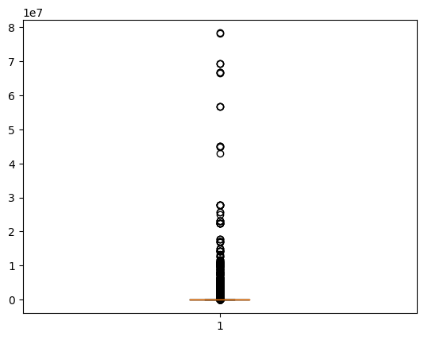

```python
#Create a boxplot of the Reviews column

plt.boxplot(inp1.Reviews)
plt.show()
```

```python
#Check records with 1 million reviews
inp1[inp1.Reviews >= 10000000]
```

|  | App | Category | Rating | Reviews | Size | Installs | Type | Price | Content Rating | Genres | Last Updated | Current Ver | Android Ver |
| --- | --- | --- | --- | --- | --- | --- | --- | --- | --- | --- | --- | --- | --- |
| 335 | Messenger – Text and Video Chat for Free | COMMUNICATION | 4.0 | 56642847 | 21516.529524 | 1000000000 | Free | 0.0 | Everyone | Communication | August 1, 2018 | Varies with device | Varies with device |
| 336 | WhatsApp Messenger | COMMUNICATION | 4.4 | 69119316 | 21516.529524 | 1000000000 | Free | 0.0 | Everyone | Communication | August 3, 2018 | Varies with device | Varies with device |
| 342 | Viber Messenger | COMMUNICATION | 4.3 | 11334799 | 21516.529524 | 500000000 | Free | 0.0 | Everyone | Communication | July 18, 2018 | Varies with device | Varies with device |
| 378 | UC Browser - Fast Download Private & Secure | COMMUNICATION | 4.5 | 17712922 | 40000.000000 | 500000000 | Free | 0.0 | Teen | Communication | August 2, 2018 | 12.8.5.1121 | 4.0 and up |
| 381 | WhatsApp Messenger | COMMUNICATION | 4.4 | 69119316 | 21516.529524 | 1000000000 | Free | 0.0 | Everyone | Communication | August 3, 2018 | Varies with device | Varies with device |
| ... | ... | ... | ... | ... | ... | ... | ... | ... | ... | ... | ... | ... | ... |
| 6449 | BBM - Free Calls & Messages | COMMUNICATION | 4.3 | 12843436 | 21516.529524 | 100000000 | Free | 0.0 | Everyone | Communication | August 2, 2018 | Varies with device | 4.0.3 and up |
| 7536 | Security Master - Antivirus, VPN, AppLock, Boo... | TOOLS | 4.7 | 24900999 | 21516.529524 | 500000000 | Free | 0.0 | Everyone | Tools | August 4, 2018 | 4.6.6 | Varies with device |
| 7937 | Shadow Fight 2 | GAME | 4.6 | 10981850 | 88000.000000 | 100000000 | Free | 0.0 | Everyone 10+ | Action | July 2, 2018 | 1.9.38 | 3.0 and up |
| 8894 | Cache Cleaner-DU Speed Booster (booster & clea... | TOOLS | 4.5 | 12759815 | 15000.000000 | 100000000 | Free | 0.0 | Everyone | Tools | July 25, 2018 | 3.1.2 | 4.0 and up |
| 8896 | DU Battery Saver - Battery Charger & Battery Life | TOOLS | 4.5 | 13479633 | 14000.000000 | 100000000 | Free | 0.0 | Everyone | Tools | June 5, 2018 | 4.8.7.8 | 4.0 and up |

92 rows × 13 columns

```python
#Drop the above records

inp1 = inp1[inp1.Reviews <= 1000000]
inp1.shape
```

```
(8634, 13)
```

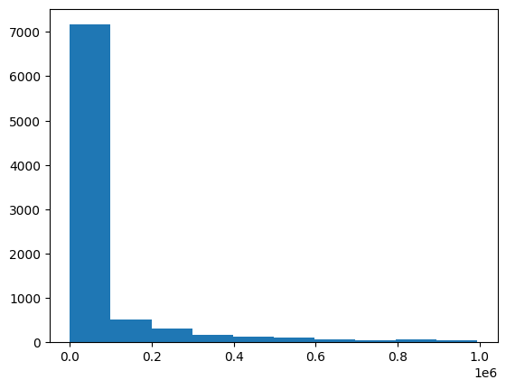

```python
#Question - Create a histogram again and check the peaks

plt.hist(inp1.Reviews)
plt.show()
```

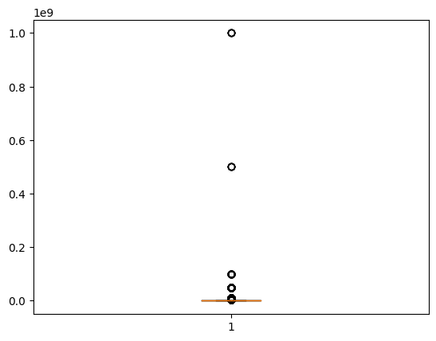

```
count    8.634000e+03
mean     4.288536e+06
std      2.864650e+07
min      5.000000e+00
25%      1.000000e+04
50%      1.000000e+05
75%      1.000000e+06
max      1.000000e+09
Name: Installs, dtype: float64
```

```python
#Question - Create a box plot for the Installs column and report back the IQR
plt.boxplot(inp1.Installs)
plt.show()

inp1.Installs.describe()
```

```python
#Question - CLean the Installs by removing all the apps having more than or equal to 100 million installs
inp1 = inp1[inp1.Installs <= 100000000]
inp1.Installs.describe()
inp1.shape
```

```
(8624, 13)
```

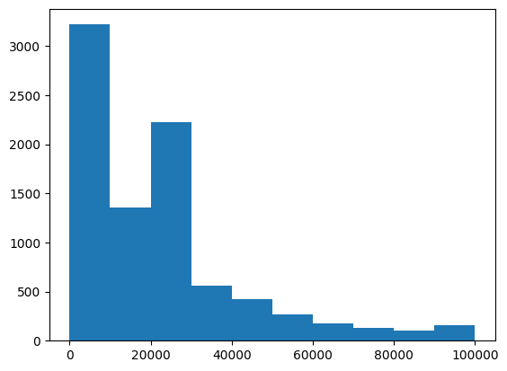

```python
#Plot a histogram for Size as well.
plt.hist(inp1.Size)
plt.show()
```

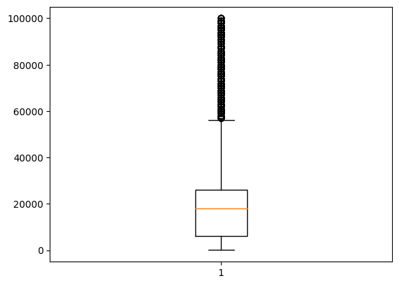

```
count      8624.000000
mean      21634.926354
std       20668.248638
min           8.500000
25%        6000.000000
50%       18000.000000
75%       26000.000000
max      100000.000000
Name: Size, dtype: float64
```

```python
#Question - Create a boxplot for the Size column and report back the median value
plt.boxplot(inp1.Size)
plt.show()
inp1.Size.describe()
```

### Session 2 - Data Visualisation with Seaborn

Seaborn is Python library to create statistical graphs easily. It is built on top of matplotlib and closely integrated with pandas.

*Functionalities of Seaborn* :

- Dataset oriented API
- Analysing univariate and bivariate distributions
- Automatic estimation and plotting of linear regression models
- Convenient views for complex datasets
- Concise control over style
- Colour palettes

```python
#import the necessary libraries
import warnings
warnings.filterwarnings("ignore")

import seaborn as sns
```

#### Distribution Plots

A distribution plot is pretty similar to the histogram functionality in matplotlib. Instead of a frequency plot, it plots an approximate probability density for that rating bucket. And the curve (or the **KDE**) that gets drawn over the distribution is the approximate probability density curve.

The following is an example of a distribution plot. Notice that now instead of frequency on the left axis, it has the density for each bin or bucket.

[figure not shown]

You'll be using sns.distplot for plotting a distribution plot. Check out its official documentation: https://seaborn.pydata.org/generated/seaborn.distplot.html

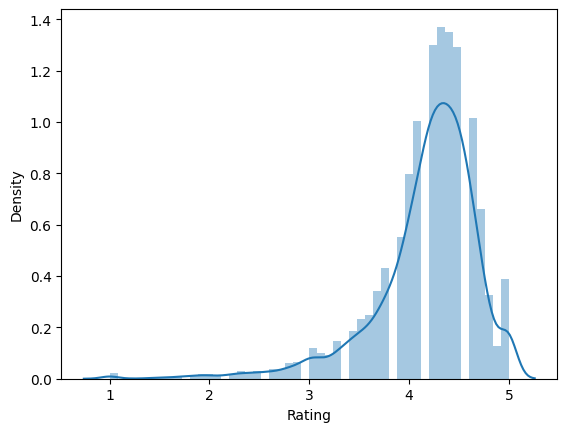

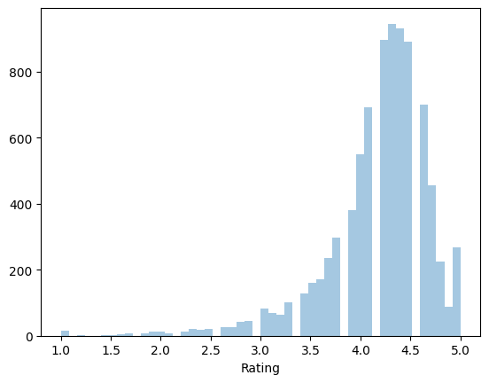

```python
#Create a distribution plot for rating
# inp1.Rating.plot.hist()
# plt.show()

# using seaborn

sns.distplot(inp1.Rating)
plt.show()

# removing the density plot
sns.distplot(inp1.Rating, kde=False)
plt.show()
```

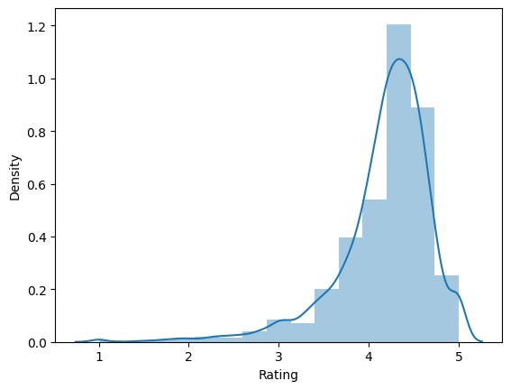

```python
#Change the number of bins

sns.distplot(inp1.Rating, bins=15)
plt.show()
```

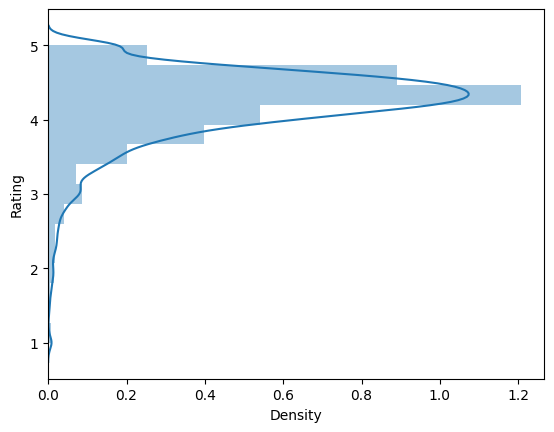

```python
# Rotate the plot
sns.distplot(inp1.Rating, bins=15, vertical=True)
plt.show()
```

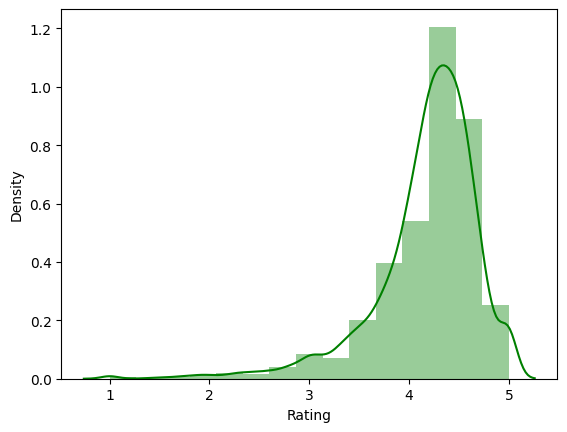

```python
#Change the colour of bins to green
sns.distplot(inp1.Rating, bins=15, color="green")
plt.show()
```

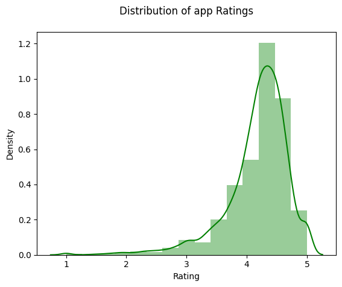

```python
#Apply matplotlib functionalities

## adding  title using matplotlib
sns.distplot(inp1.Rating, bins=15, color="green")
plt.title('Distribution of app Ratings\n', fontdict= {"fontsize": 12})
plt.show()
```

#### Styling Options

One of the biggest advantages of using Seaborn is that you can retain its aesthetic properties and also the Matplotlib functionalities to perform additional customisations. Before we continue with our case study analysis, let’s study some styling options that are available in Seaborn.

- Check out the official documentation:https://seaborn.pydata.org/generated/seaborn.set_style.html

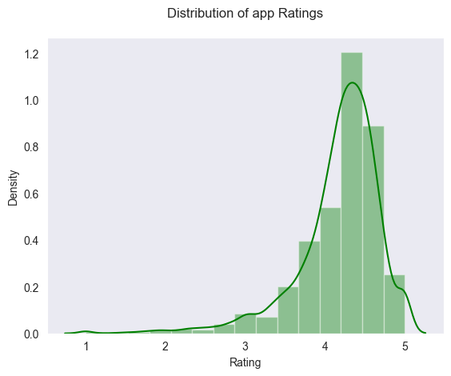

```python
#Check all the styling options
sns.set_style("dark")
sns.distplot(inp1.Rating, bins=15, color="green")
plt.title('Distribution of app Ratings\n', fontdict= {"fontsize": 12})
plt.show()
```

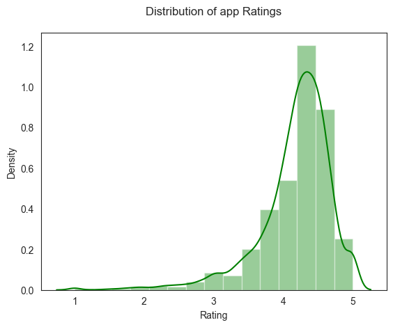

```python
sns.set_style("white")
sns.distplot(inp1.Rating, bins=15, color="green")
plt.title('Distribution of app Ratings\n', fontdict= {"fontsize": 12})
plt.show()
```

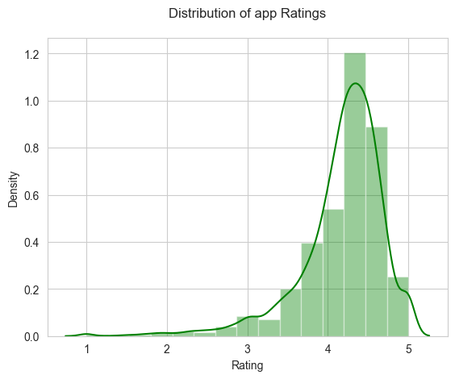

```python
sns.set_style("whitegrid")
sns.distplot(inp1.Rating, bins=15, color="green")
plt.title('Distribution of app Ratings\n', fontdict= {"fontsize": 12})
plt.show()
```

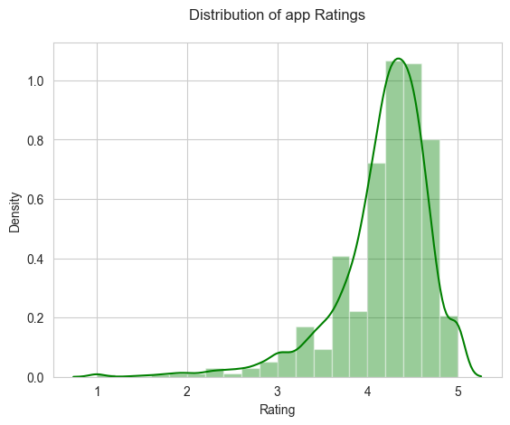

```python
#Change the number of bins to 20

sns.distplot(inp1.Rating, bins=20, color="green")
plt.title('Distribution of app Ratings\n', fontdict= {"fontsize": 12})
plt.show()
```

```python
# Matplotlib styles and themes

plt.style.available
```

```
['Solarize_Light2',
 '_classic_test_patch',
 '_mpl-gallery',
 '_mpl-gallery-nogrid',
 'bmh',
 'classic',
 'dark_background',
 'fast',
 'fivethirtyeight',
 'ggplot',
 'grayscale',
 'seaborn-v0_8',
 'seaborn-v0_8-bright',
 'seaborn-v0_8-colorblind',
 'seaborn-v0_8-dark',
 'seaborn-v0_8-dark-palette',
 'seaborn-v0_8-darkgrid',
 'seaborn-v0_8-deep',
 'seaborn-v0_8-muted',
 'seaborn-v0_8-notebook',
 'seaborn-v0_8-paper',
 'seaborn-v0_8-pastel',
 'seaborn-v0_8-poster',
 'seaborn-v0_8-talk',
 'seaborn-v0_8-ticks',
 'seaborn-v0_8-white',
 'seaborn-v0_8-whitegrid',
 'tableau-colorblind10']
```

```python
plt.style.use("tableau-colorblind10")
```

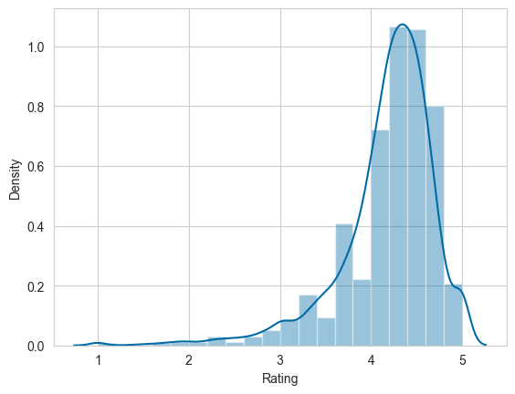

```python
sns.distplot(inp1.Rating,bins=20)
plt.show()
```

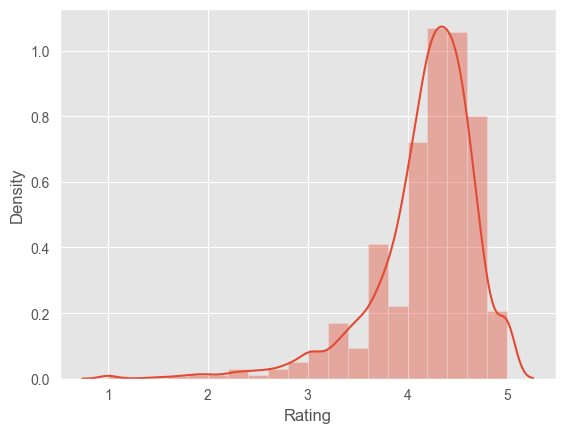

```python
plt.style.use("ggplot")
sns.distplot(inp1.Rating,bins=20)
plt.show()
```

```python
## setting the styles to default

plt.style.use("default")
%matplotlib inline
```

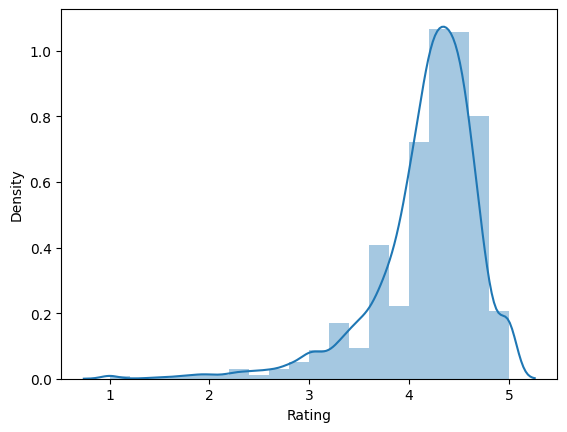

```python
sns.distplot(inp1.Rating,bins=20)
plt.show()
```

#### Pie-Chart and Bar Chart

For example, if you want to visualise the responses of a marketing campaign, you can use the following views:

[figure not shown]

- You'll be using the pandas method of plotting both a pie chart and a bar chart. Check out their official documentations:
  - https://pandas.pydata.org/pandas-docs/stable/reference/api/pandas.DataFrame.plot.bar.html
  - https://pandas.pydata.org/pandas-docs/stable/reference/api/pandas.DataFrame.plot.pie.html

```python
#Analyse the Content Rating column
inp1['Content Rating'].value_counts()
```

```
Everyone           6938
Teen                928
Mature 17+          417
Everyone 10+        337
Adults only 18+       3
Unrated               1
Name: Content Rating, dtype: int64
```

```python
#Remove the rows with values which are less represented
inp1 = inp1[~ (inp1['Content Rating'].isin(['Adults only 18+', 'Unrated']))]
inp1['Content Rating'].value_counts()
```

```
Everyone        6938
Teen             928
Mature 17+       417
Everyone 10+     337
Name: Content Rating, dtype: int64
```

```python
#Reset the index
inp1.reset_index(inplace=True, drop=True)
inp1.info()
```

```
<class 'pandas.core.frame.DataFrame'>
RangeIndex: 8620 entries, 0 to 8619
Data columns (total 13 columns):
 #   Column          Non-Null Count  Dtype
---  ------          --------------  -----
 0   App             8620 non-null   object
 1   Category        8620 non-null   object
 2   Rating          8620 non-null   float64
 3   Reviews         8620 non-null   int32
 4   Size            8620 non-null   float64
 5   Installs        8620 non-null   int32
 6   Type            8620 non-null   object
 7   Price           8620 non-null   float64
 8   Content Rating  8620 non-null   object
 9   Genres          8620 non-null   object
 10  Last Updated    8620 non-null   object
 11  Current Ver     8620 non-null   object
 12  Android Ver     8620 non-null   object
dtypes: float64(3), int32(2), object(8)
memory usage: 808.2+ KB
```

```python
#Check the apps belonging to different categories of Content Rating
inp1['Content Rating'].value_counts()
```

```
Everyone        6938
Teen             928
Mature 17+       417
Everyone 10+     337
Name: Content Rating, dtype: int64
```

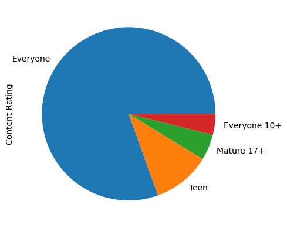

```python
#Plot a pie chart
inp1['Content Rating'].value_counts().plot.pie()
plt.show()
```

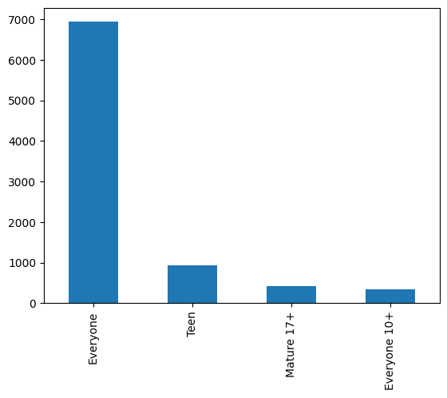

```python
#Plot a bar chart
inp1['Content Rating'].value_counts().plot.bar()
plt.show()
```

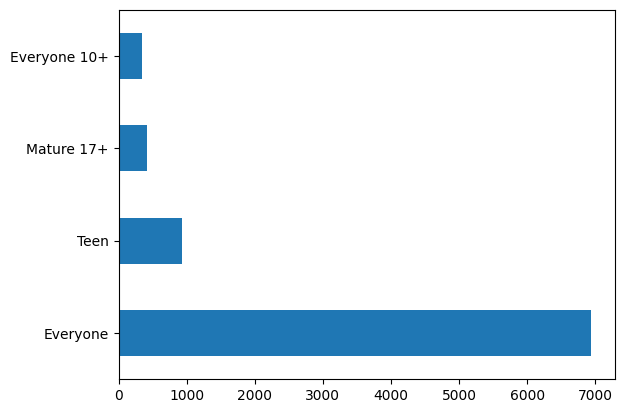

```python
#Question - Plot a bar plot for checking the 4th highest Android version type
inp1['Content Rating'].value_counts().plot.barh()
plt.show()
```

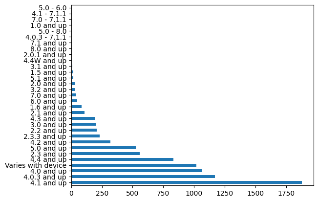

```python
inp1['Android Ver'].value_counts().plot.barh()
plt.show()
```

#### Scatter Plots

Scatterplots are perhaps one of the most commonly used as well one of the most powerful visualisations you can use in the field of machine learning. They are pretty crucial in revealing relationships between the data points and you can generally deduce some sort of trends in the data with the help of a scatter plot.

[figure not shown]

- They're pretty useful in regression problems to check whether a linear trend exists in the data or not. For example, in the image below, creating a linear model in the first case makes far more sense since a clear straight line trend is visible.

[figure not shown]

- Also, they help in observing **naturally occuring clusters**. In the following image, the marks of students in Maths and Biology has been plotted.You can clearly group the students to 4 clusters now. Cluster 1 are students who score very well in Biology but very poorly in Maths, Cluster 2 are students who score equally well in both the subjects and so on.

[figure not shown]

**Note**: You'll be studying about both Regression and Clustering in greater detail in the machine learning modules

You'll be using **sns.jointplot()** for creating a scatter plot. Check out its documentation: https://seaborn.pydata.org/generated/seaborn.jointplot.html

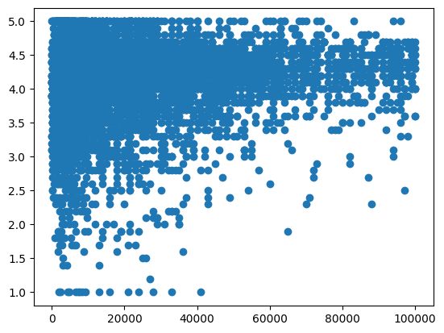

```python
###Size vs Rating

##Plot a scatter-plot in the matplotlib way between Size and Rating

plt.scatter(inp1.Size, inp1.Rating)
```

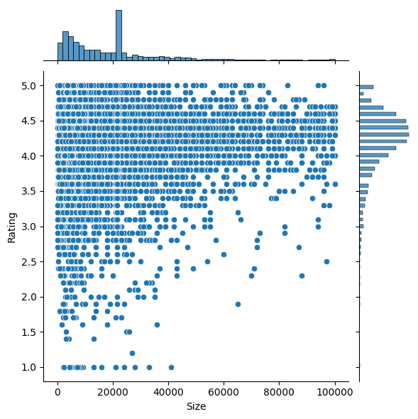

```python
### Plot the same thing now using a jointplot
sns.jointplot(inp1, x=inp1.Size, y=inp1.Rating)
plt.show()
```

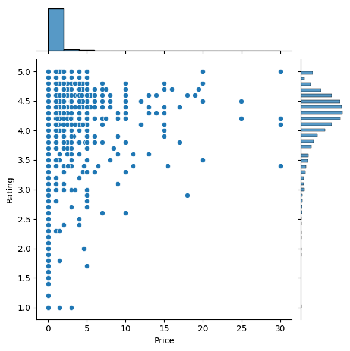

```python
## Plot a jointplot for Price and Rating
sns.jointplot(inp1, x=inp1.Price, y=inp1.Rating)
plt.show()
```

**Reg Plots**

- These are an extension to the jointplots, where a regression line is added to the view

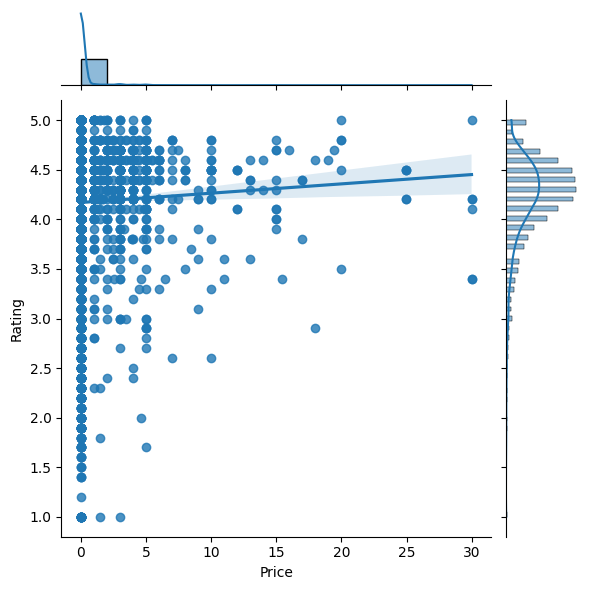

```python
##Plot a reg plot for Price and Rating and observe the trend
sns.jointplot(inp1, x=inp1.Price, y=inp1.Rating, kind="reg")
plt.show()
```

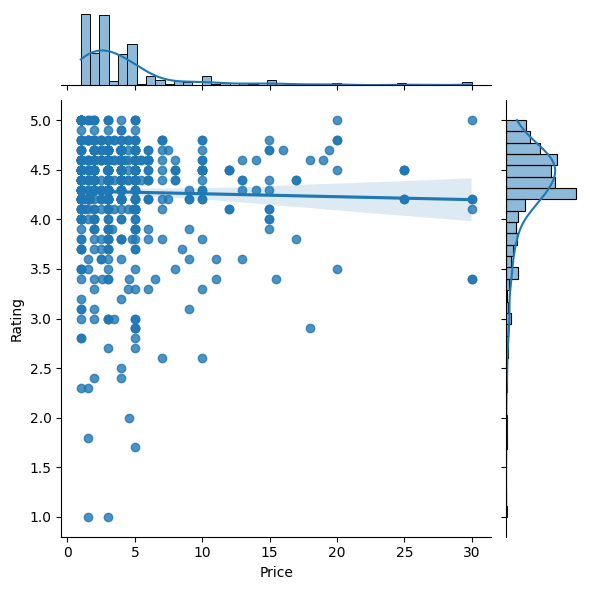

```python
## Question - Plot a reg plot for Price and Rating again for only the paid apps.
paid_apps = inp1[inp1.Price > 0]
paid_apps

sns.jointplot(paid_apps,x=paid_apps.Price, y=paid_apps.Rating, kind="reg")
plt.show()
```

**Pair Plots**

- When you have several numeric variables, making multiple scatter plots becomes rather tedious. Therefore, a pair plot visualisation is preferred where all the scatter plots are in a single view in the form of a matrix
- For the non-diagonal views, it plots a **scatter plot** between 2 numeric variables
- For the diagonal views, it plots a **histogram**

Pair Plots help in identifying the trends between a target variable and the predictor variables pretty quickly. For example, say you want to predict how your company’s profits are affected by three different factors. In order to choose which you created a pair plot containing profits and the three different factors as the variables. Here are the scatterplots of profits vs the three variables that you obtained from the pair plot.

[figure not shown]

It is clearly visible that the left-most factor is the most prominently related to the profits, given how linearly scattered the points are and how randomly scattered the rest two factors are.

You'll be using **sns.pairplot()** for this visualisation. Check out its official documentation:https://seaborn.pydata.org/generated/seaborn.pairplot.html

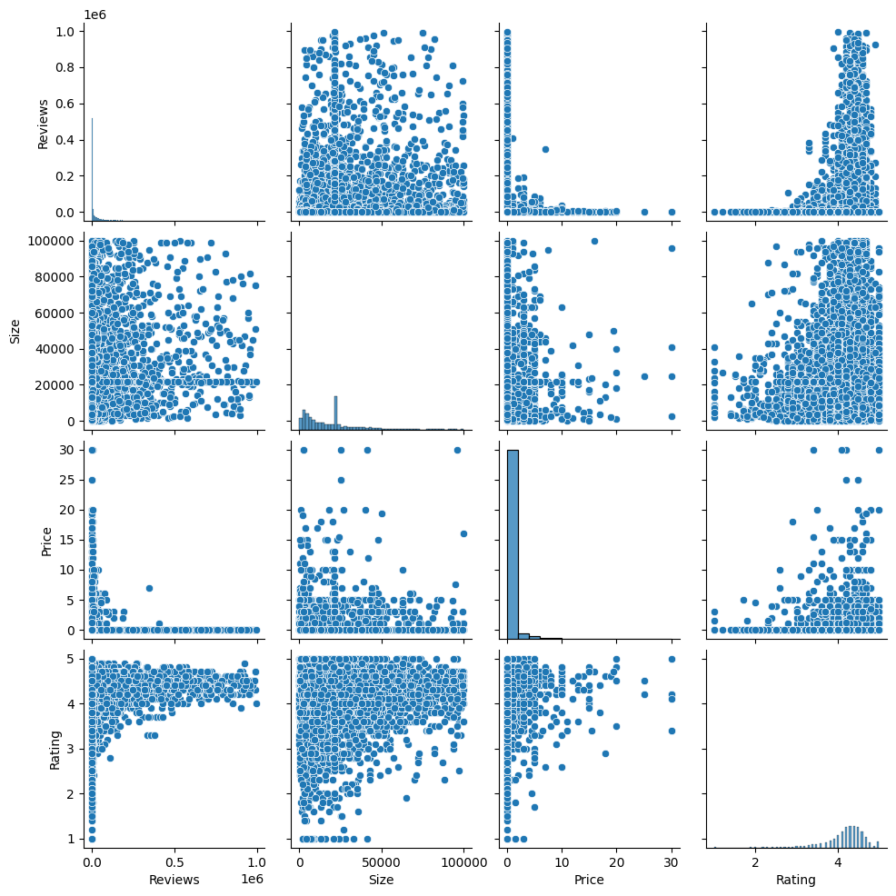

```python
## Create a pair plot for Reviews, Size, Price and Rating

sns.pairplot(inp1[['Reviews', 'Size', 'Price', 'Rating']])
plt.show()
```

**Bar Charts Revisited**

- Here, you'll be using bar charts once again, this time using the **sns.barplot()** function. Check out its official documentation:https://seaborn.pydata.org/generated/seaborn.barplot.html
- You can modify the **estimator** parameter to change the aggregation value of your barplot

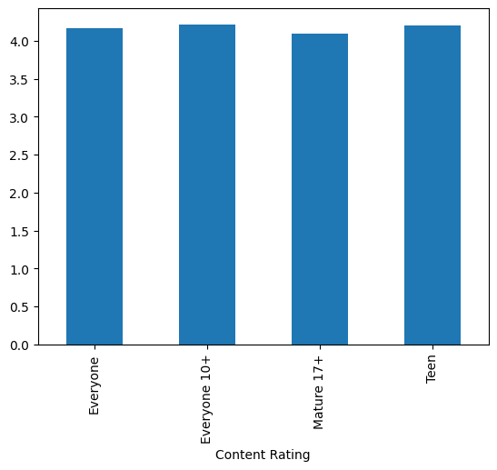

```python
##Plot a bar plot of Content Rating vs Average Rating
inp1.groupby(by=(['Content Rating']))['Rating'].mean().plot.bar()
plt.show()
```

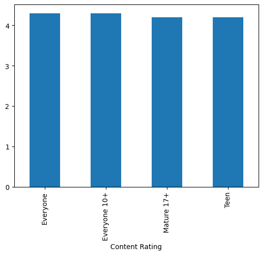

```python
inp1.groupby(by=(['Content Rating']))['Rating'].median().plot.bar()
plt.show()
```

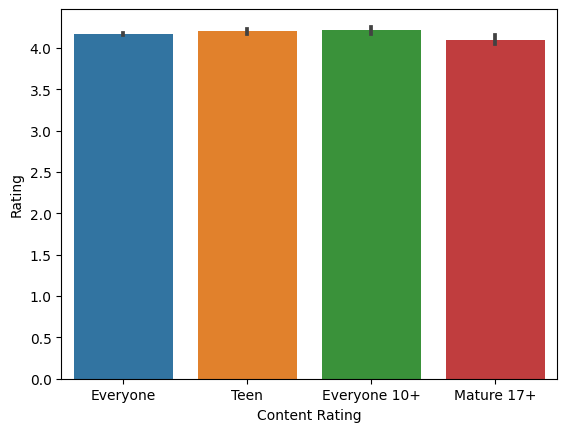

```python
## using seaborn

sns.barplot(data=inp1, x=inp1['Content Rating'], y=inp1.Rating)
```

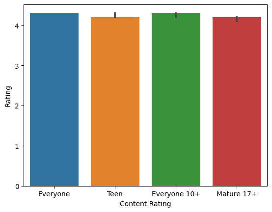

```python
##Plot the above bar plot using the estimator parameter

sns.barplot(data=inp1, x=inp1['Content Rating'], y=inp1.Rating, estimator=np.median)
plt.show()
```

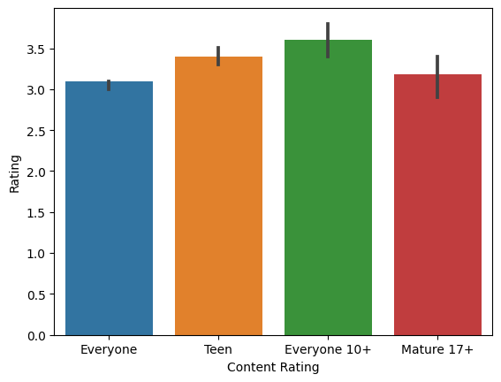

```python
##Plot the bar plot with only the 5th percentile of Ratings
sns.barplot(data=inp1, x=inp1['Content Rating'], y=inp1.Rating, estimator=lambda x: np.quantile(x,0.05))
plt.show()
```

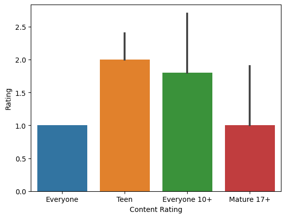

```python
##Question - Plot the bar plot with the minimum Rating
sns.barplot(data=inp1, x=inp1['Content Rating'], y=inp1.Rating, estimator=np.min)
plt.show()
```

**Box Plots Revisited**

- Apart from outlier analysis, box plots are great at comparing the spread and analysing a numerical variable across several categories
- Here you'll be using **sns.boxplot()** function to plot the visualisation. Check out its documentation: https://seaborn.pydata.org/generated/seaborn.boxplot.html

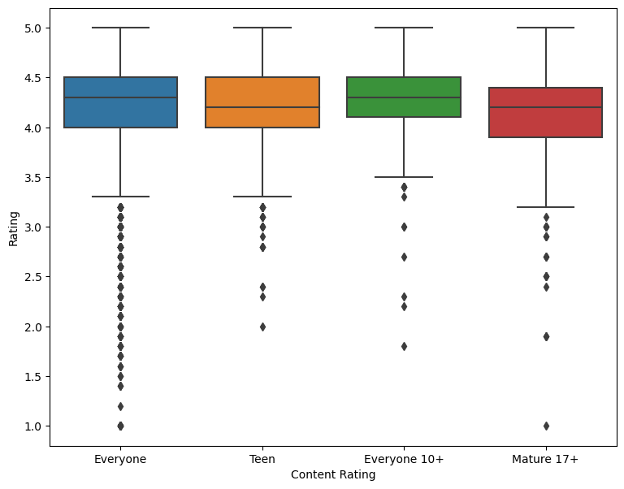

```python
##Plot a box plot of Rating vs Content Rating
plt.figure(figsize=[9,7])
sns.boxplot(inp1,x=inp1['Content Rating'], y=inp1['Rating'])
```

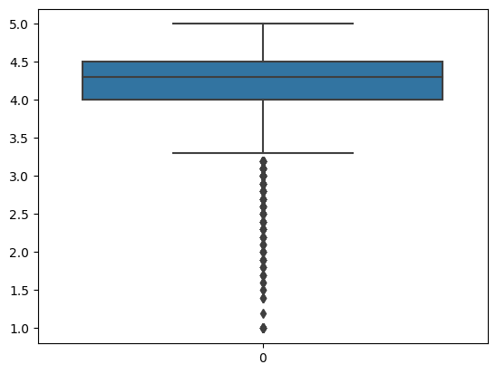

```python
##Question - Plot a box plot for the Rating column only

sns.boxplot(inp1.Rating)
```

```python
##Question - Plot a box plot of Ratings across the 4 most popular Genres
inp1.Genres.value_counts()
top_4_genres = inp1[inp1.Genres.isin(['Tools', 'Entertainment', 'Medical','Education'])]
top_4_genres.Genres.value_counts()
```

```
Tools            694
Entertainment    508
Education        464
Medical          344
Name: Genres, dtype: int64
```

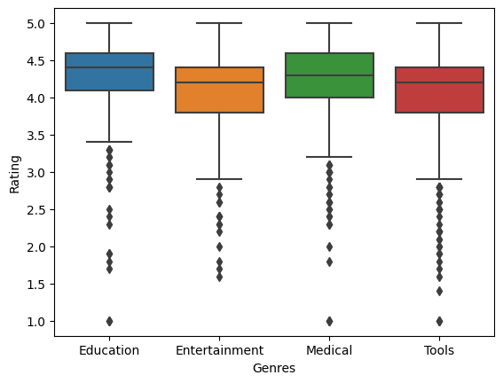

```python
sns.boxplot(top_4_genres, x=top_4_genres.Genres, y=top_4_genres.Rating)
plt.show()
```

#### Heat Maps

Heat mapsutilise the concept of using colours and colour intensities to visualise a range of values. You must have seen heat maps in cricket or football broadcasts on television to denote the players’ areas of strength and weakness.

[figure not shown]

- In python, you can create a heat map whenever you have a rectangular grid or table of numbers analysing any two features

[figure not shown]

- You'll be using **sns.heatmap()** to plot the visualisation. Checkout its official documentation :https://seaborn.pydata.org/generated/seaborn.heatmap.html

```python
##Ratings vs Size vs Content Rating

##Prepare buckets for the Size column using pd.qcut
inp1['Size_bucket'] = pd.qcut(inp1.Size, [0,0.2,0.4,0.6,0.8,1], ['VL','L','M','H', 'VH'])
inp1.head()
```

|  | App | Category | Rating | Reviews | Size | Installs | Type | Price | Content Rating | Genres | Last Updated | Current Ver | Android Ver | Size_bucket |
| --- | --- | --- | --- | --- | --- | --- | --- | --- | --- | --- | --- | --- | --- | --- |
| 0 | Photo Editor & Candy Camera & Grid & ScrapBook | ART_AND_DESIGN | 4.1 | 159 | 19000.0 | 10000 | Free | 0.0 | Everyone | Art & Design | January 7, 2018 | 1.0.0 | 4.0.3 and up | M |
| 1 | Coloring book moana | ART_AND_DESIGN | 3.9 | 967 | 14000.0 | 500000 | Free | 0.0 | Everyone | Art & Design;Pretend Play | January 15, 2018 | 2.0.0 | 4.0.3 and up | M |
| 2 | U Launcher Lite – FREE Live Cool Themes, Hide ... | ART_AND_DESIGN | 4.7 | 87510 | 8700.0 | 5000000 | Free | 0.0 | Everyone | Art & Design | August 1, 2018 | 1.2.4 | 4.0.3 and up | L |
| 3 | Sketch - Draw & Paint | ART_AND_DESIGN | 4.5 | 215644 | 25000.0 | 50000000 | Free | 0.0 | Teen | Art & Design | June 8, 2018 | Varies with device | 4.2 and up | H |
| 4 | Pixel Draw - Number Art Coloring Book | ART_AND_DESIGN | 4.3 | 967 | 2800.0 | 100000 | Free | 0.0 | Everyone | Art & Design;Creativity | June 20, 2018 | 1.1 | 4.4 and up | VL |

```python
##Create a pivot table for Size_buckets and Content Rating with values set to Rating
pd.pivot_table(data=inp1, index='Content Rating', columns='Size_bucket',values="Rating", aggfunc=np.mean)
```

| Size_bucket Content Rating | VL | L | M | H | VH |
| --- | --- | --- | --- | --- | --- |
| Everyone | 4.117536 | 4.158405 | 4.215784 | 4.170799 | 4.187302 |
| Everyone 10+ | 4.189474 | 4.207407 | 4.238318 | 4.193443 | 4.217073 |
| Mature 17+ | 3.978947 | 4.124211 | 4.021705 | 4.155172 | 4.193814 |
| Teen | 4.184848 | 4.233094 | 4.143310 | 4.198131 | 4.246154 |

```python
##Change the aggregation to median
pd.pivot_table(data=inp1, index='Content Rating', columns='Size_bucket',values="Rating", aggfunc=np.median)
```

| Size_bucket Content Rating | VL | L | M | H | VH |
| --- | --- | --- | --- | --- | --- |
| Everyone | 4.20 | 4.3 | 4.3 | 4.3 | 4.3 |
| Everyone 10+ | 4.10 | 4.3 | 4.3 | 4.3 | 4.3 |
| Mature 17+ | 4.25 | 4.2 | 4.1 | 4.1 | 4.2 |
| Teen | 4.20 | 4.3 | 4.2 | 4.2 | 4.3 |

```python
##Change the aggregation to 20th percentile
pd.pivot_table(data=inp1, index='Content Rating', columns='Size_bucket',values="Rating", aggfunc=lambda x: np.quantile(x,0.2))
```

| Size_bucket Content Rating | VL | L | M | H | VH |
| --- | --- | --- | --- | --- | --- |
| Everyone | 3.80 | 3.80 | 4.0 | 3.8 | 3.9 |
| Everyone 10+ | 3.86 | 3.92 | 4.1 | 4.0 | 4.0 |
| Mature 17+ | 3.30 | 3.68 | 3.7 | 3.9 | 4.0 |
| Teen | 3.80 | 3.90 | 3.9 | 4.0 | 4.0 |

```python
##Store the pivot table in a separate variable
res = pd.pivot_table(data=inp1, index='Content Rating', columns='Size_bucket',values="Rating", aggfunc=lambda x: np.quantile(x,0.2))
```

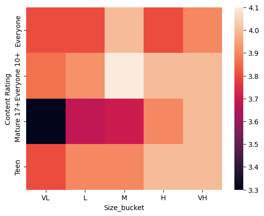

```python
##Plot a heat map
sns.heatmap(res)
```

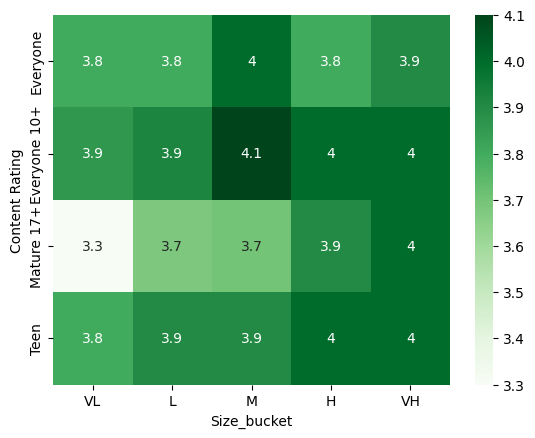

```python
##Apply customisations
sns.heatmap(res, cmap="Greens", annot=True)
plt.show()
```

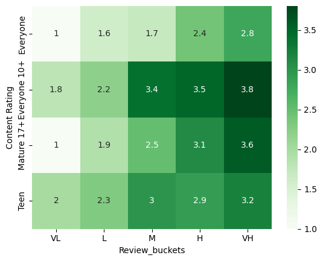

```python
##Question - Replace Content Rating with Review_buckets in the above heat map
##Keep the aggregation at minimum value for Rating

inp1.head()
inp1['Review_buckets'] = pd.qcut(inp1.Reviews, [0,0.2,0.4,0.6,0.8,1], ['VL','L','M','H', 'VH'])

res = pd.pivot_table(data=inp1, index='Content Rating', columns='Review_buckets',values="Rating", aggfunc=np.min)
sns.heatmap(res, cmap = "Greens", annot=True)
plt.show()
```

### Session 3: Additional Visualisations

#### Line Plots

- A line plot tries to observe trends using time dependent data.
- For this part, you'll be using **pd.to_datetime()** function. Check out its documentation:https://pandas.pydata.org/pandas-docs/stable/reference/api/pandas.to_datetime.html

```python
## Extract the month from the Last Updated Date

# inp1['updated_month'] = pd.DatetimeIndex(inp1['Last Updated']).month              ## using DatetimeIndex

inp1['updated_month'] = pd.to_datetime(inp1['Last Updated']).dt.month               ## using to_datetime()
```

```python
## Find the average Rating across all the months
inp1.groupby(by=(['updated_month']))['Rating'].mean()
```

```
updated_month
1     4.143842
2     4.090385
3     4.107963
4     4.148326
5     4.153375
6     4.172590
7     4.222968
8     4.271086
9     4.041406
10    4.012739
11    4.102685
12    4.065350
Name: Rating, dtype: float64
```

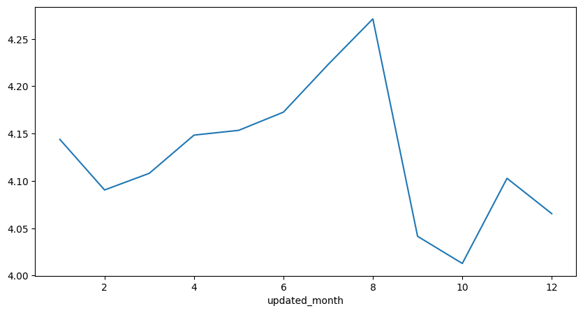

```python
## Plot a line graph
plt.figure(figsize=[10,5])
inp1.groupby(by=(['updated_month']))['Rating'].mean().plot()
```

#### Stacked Bar Charts

- A stacked bar chart breaks down each bar of the bar chart on the basis of a different category
- For example, for the Campaign Response bar chart you saw earlier, the stacked bar chart is also showing the Gender bifurcation as well

[figure not shown]

```python
## Create a pivot table for Content Rating and updated Month with the values set to Installs
pd.pivot_table(data=inp1,index='updated_month', values='Installs', columns='Content Rating', aggfunc=sum )
```

| Content Rating updated_month | Everyone | Everyone 10+ | Mature 17+ | Teen |
| --- | --- | --- | --- | --- |
| 1 | 925387390 | 105282000 | 9701210 | 44159010 |
| 2 | 545372005 | 19821000 | 13021500 | 39597710 |
| 3 | 695365520 | 30322510 | 9111100 | 79850310 |
| 4 | 973371180 | 23300000 | 5259000 | 161619410 |
| 5 | 1861067800 | 118173500 | 50140100 | 202689600 |
| 6 | 2427170505 | 317727100 | 145257200 | 415716600 |
| 7 | 7771109680 | 456556000 | 419491910 | 1943556800 |
| 8 | 5930943320 | 215821000 | 312981700 | 1257855650 |
| 9 | 260340410 | 24931100 | 2201010 | 22483100 |
| 10 | 258279680 | 23101000 | 3160000 | 45629210 |
| 11 | 625424710 | 60310000 | 1070100 | 31261100 |
| 12 | 567105770 | 8410000 | 12960100 | 51707100 |

```python
#### just trying diff view
# monthly2 =  pd.pivot_table(data=inp1,index='Content Rating', values='Installs', columns='updated_month', aggfunc=sum )
# monthly2.plot(kind="bar", stacked="True", figsize=[10,7])
```

```python
##Store the table in a separate variable
monthly = pd.pivot_table(data=inp1,index='updated_month', values='Installs', columns='Content Rating', aggfunc=sum )
```

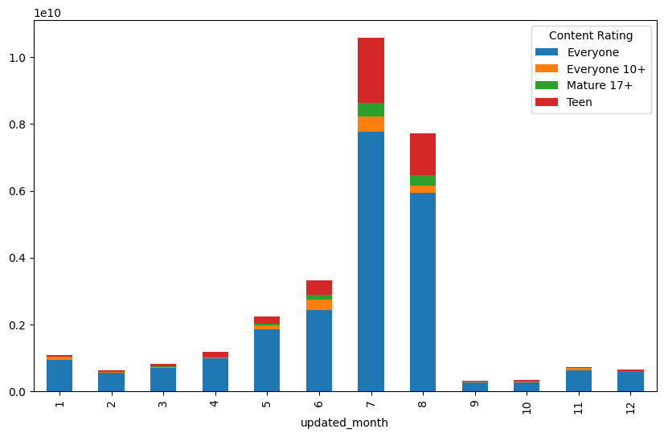

```python
##Plot the stacked bar chart.
monthly.plot(kind='bar', stacked="True", figsize=[10,6])
plt.show()
```

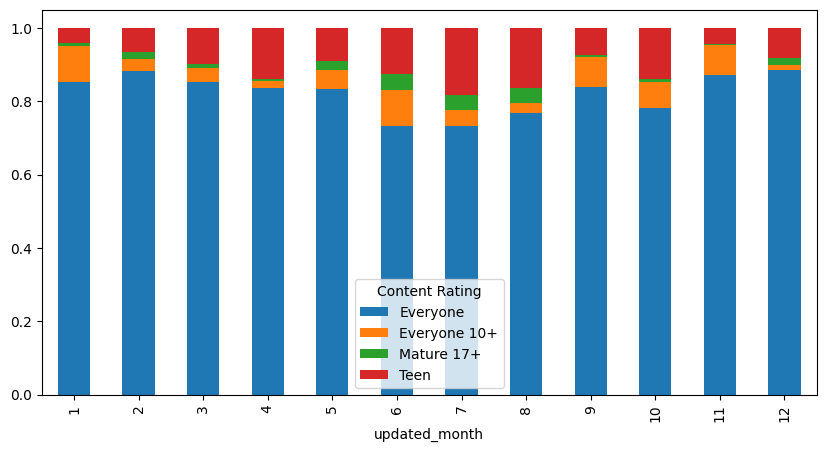

```python
##Plot the stacked bar chart again wrt to the proportions.

## calculate the propotions/percentages insted of absolute values
moonthly_perc = monthly[['Everyone','Everyone 10+','Mature 17+','Teen']].apply(lambda x: x/x.sum(), axis=1)


moonthly_perc.plot(kind="bar", stacked="True", figsize=[10,5])
```

Summary of case study:

-- First, you did a fair bit of data handling and cleaning - cleaning junk records, adding missing values, changing data types, remove outliers, etc.  
-- When you analysed the ratings using the histogram, you saw that they are skewed towards higher ratings.  
-- Using a bar chart, you saw that most of the apps belong to the Everyone category.  
-- You also observed a weak trend between the ratings and the size of the app, using a scatter-plot. You also briefly forayed to reg plots to understand its nuances.  
-- Using a pair-plot, you were able to see multiple scatter plots and draw several inferences, for example, price and rating having very weak trend, reviews and price being inversely related and so on.  
-- After that, you utilised estimator functions along with bar plots as well as box plots to observe the spread of ratings across the different Content Rating Categories. Here, your main observation was that Everyone category has a lot of apps having very low ratings.  
-- Finally, you created a heat map comparing the ratings across different Reviews and Content Rating buckets.

#### Plotly

Plotly is a Python library used for creating interactive visual charts. You can take a look at how you can use it to create aesthetic looking plots with a lot of user-friendly functionalities like hover, zoom, etc.

Check out this link for installation and documentation:https://plot.ly/python/getting-started/

```python
#Install plotly
# pip install ploty
```

```python
#Take the table you want to plot in a separate variable
result = inp1.groupby(by=(['updated_month']))[['Rating']].mean()
result.reset_index(inplace=True)
result
```

|  | updated_month | Rating |
| --- | --- | --- |
| 0 | 1 | 4.143842 |
| 1 | 2 | 4.090385 |
| 2 | 3 | 4.107963 |
| 3 | 4 | 4.148326 |
| 4 | 5 | 4.153375 |
| 5 | 6 | 4.172590 |
| 6 | 7 | 4.222968 |
| 7 | 8 | 4.271086 |
| 8 | 9 | 4.041406 |
| 9 | 10 | 4.012739 |
| 10 | 11 | 4.102685 |
| 11 | 12 | 4.065350 |

```python
#Import the plotly libraries
import plotly.express as px
```

```python
#Prepare the plot
fig = px.line(res, x= "updated_month", y="Rating", title="Monthly average rating")
fig.show()
```